# An Introduction Options

Mick Cooney mickcooney@gmail.com

2019-03-30

# 1 First Post

> “If you intelligently trade derivatives, it’s like a license to steal” - Charlie Munger

I have spent most of my professional life as a ‘quant’ - a term in finance that is short for quantitative analyst - a person who performs statistical analysis on financial data for all sorts of different reasons, but usually focused on providing a competitive advantage to a firm’s trading strategies.

The above quote was made in mid-2014, and succinctly summarises why small financial firms can make such huge profits despite neither having the technical advantages that firms engaging in currently-controversial high-frequency trading (HFT) strategies, nor the scale and diversified advantages enjoyed by well-known investment banks like Goldman Sachs and Morgan Stanley.

By the time this series is finished, I aim to help people understand why this is possible, what is it about options that allows for such profitable trading? In the securities business, it is not uncommon for small-sized firms to excel at their primary business, and not because they engage in deceitful, fraudulent or exploitative practices.

Generally, it is because they have identified an edge over the competition. This edge can come in different forms, and one such form is knowledge-based. They know something the rest of the market does not.

Options allow this for a simple reason: they are complex, and most people do not understand them. Hopefully, this article will help you with this.

I will gloss over some technical points for the purposes of clarity - though not too much. My aim is the Einsteinian principle of “as simple as possible, but not simpler”.

There are many sources on pricing methodology and other quantitative theory of options. This will not be one of them. I doubt I would do the topic justice but will provide some links at the end of the series for those interested.

Instead, I want to discuss practical issues with options, options trading, and the various trading infrastructures that are in place. A fascinating topic, it is rarely covered, despite its importance. For clarity, I will focus solely on vanilla, exchange-traded options (terms that will be explained in time), and will not discuss options with more esoteric features like path-dependent payoffs.

We will get to price and other quantitative behaviour in future articles of this series, but before that, it is important to know a little about the infrastructure and details of the options markets themselves.

## 1.1 What is an Option?

Options are derivative contracts that allow the holder the right, but not the obligation, to trade (buy or sell) a specific security for a specific price for a specific period of time. The asset for which the option confers the right to trade is termed the *underlying asset* (or underlying for short).

Any type of asset can be used as the underlying, and this article will focus on equity options (options on stocks such as Google, Apple, IBM, 3M and WalMart). It is the most common type of option, and that with which I am most familiar. Most of the principles discussed here have analogies with other underlying assets, such as currencies, futures or bonds[^1], so we do not lose much generality by this focus.

Before we begin, it is best to first lay out some terminology and notation.

A *long* position is one where the instrument is ‘owned’ by the holder, profiting from a rise in the price of that instrument. A *short* position is one where the instrument has been sold by the holder without owning it, profiting from a fall in the price.

These terms or used very generically in finance. Thus, a speculator will state she is ‘long interest rates’ - meaning they hold a combination of assets that will be profitable in the event of a rise in interest rates.

While these terms often seem to be abused - what does it mean to be ‘short gamma in US equities’ for example[^2] - the key thing to remember is that long positions want a rise in price and short positions want a decline.

An option that confers the right to buy the underlying is termed a *call option* (*call* for short); an option that confers the right to sell is termed a *put option*.

Calls and puts are very closely linked in terms of behaviour and price, called *put/call parity*, and we will discuss this in a future article.

The specified trade price for the option contract is termed the *strike price*, and the time period for which this right is conferred is the *lifetime* of the option. The date at which this right ends is the *expiration date* or *expiry date*.

Options are insurance policies against the movement of the underlying price. A call is a policy against the stock price going up, a put is a policy against the stock price going down, and the policy lasts until expiration.

Finally, most option contracts have a feature that is known as *early exercise* - that is, the right to buy or sell the stock can be exercised prior to expiration. Most options traded have this feature and are termed *American* options. This has nothing to do with geography and is presumably some historical artefact. Options that do not have early exercise are termed *European* options.

The vast majority of options traded have early exercise rights and we will largely ignore European options. They are still very important from a modelling point of view as they are easier to price than options with early exercise.[^3]

## 1.2 Option Trading Infrastructure

The mechanics of trading equity options is very similar in principle to trading other common financial assets such as equities or futures. Options are traded on an exchange, and are treated as assets in your account.

Two of the most important concerns in financial trading are *counterparty risk* and *liquidity risk*. Both important concepts, attempts at their mitigation explain the existence of a lot of infrastructure that has built up around the asset markets.[^4]

### 1.2.1 Counterparty Risk

Counterparty risk is the risk the person you trade with (your *counterparty*) is not fit or willing to make good on the trade when due.

The sudden reappearance of counterparty risk was the major contributing factor to Credit Crisis of 2008. Huge losses in subprime mortgages threatened the existence of a number of large financial institutions. As a result, other institutions that had existing agreements with the distressed counterparties were now concerned about their ability to sustain current financial agreements.

A good analogy is insurance companies. If your house burns down, you want to be sure that the company that wrote your policy is in business to pay the compensation.

Usually this is not a consideration, but if a lot of houses all burn down at once (say due to a huge forest fire) - this can become a huge problem. Very large hurricanes and natural disasters can bankrupt insurance companies, and large companies insuring against natural disasters try hard to diversify risks geographically.

Similarly, if you buy a call option and the stock rockets up through the strike price and is now worth many, many multiples of what you paid for it, you want to ensure that the person you bought it from pays up.

### 1.2.2 Liquidity Risk

*Liquidity risk* is the risk of the asset losing its *liquidity*. Liquidity is a commonly-used but nebulous term describing how difficult it is to find counterparties to trade an asset at a reasonable price. Liquid assets are easy to trade in large quantities, and such trades do not have a large effect on the price.

As you might imagine from the lack of precision in the terms used in its definition, liquidity is difficult to quantify[^5]. In broad terms, currencies tend to be extremely liquid, followed by equities and commodity futures. At the other end of the spectrum, real estate is highly illiquid, even in a booming property market[^6].

Both of these issues are serious business risks, and were even more so in the early days of finance[^7]. Such concerns led to the creation of exchanges and clearing.

An *exchange* is a legal entity that serves as a central marketplace for traders of a particular asset type. It standardises contracts - especially important for options and futures - and centralises the liquidity in a central venue.

Trading on an exchange is a special privilege given only to members of the exchange, so members either trade for themselves or act as brokers for third parties. Most participants are customers of brokers as becoming a member of an exchange is expensive, time consuming and costly. As such, it is rarely worth becoming a member unless it is a primary focus of your business.

Once a trade occurs between a buyer and seller, it is recorded on the exchange, with trade notifications sent to a number of interested parties including both primary participants in the trade, regulatory authorities, and market data providers. Most importantly, the trade is registered with the *clearing* system.

The clearing system is how trades are settled, and helps mitigate against counterparty risk: once your trade is reported it is the responsibility of the clearing system to ensure participants receive/deliver their assets and cash. Once a trade is registered your counterparty is now the clearing system NOT the person or company on the other side of your trade. Thus, counterparty risk is much reduced.[^8]

Settlement of trades usually happens a number of days after the date of trade, usually three days (for historical reasons), but attempts have begun to reduce this down to a T+1 system: cash and assets are transferred a day after the trade date.

An interesting consequence of the old T+3 settlement system is the fact that US exchanges are never closed for more three days in a row: this ensured people could always liquidate assets to meet settlement obligations. This is why an unfortunate junior trader gets the job of watching the screens on Black Friday or during the Christmas holidays, despite nothing ever really happening. Someone needs to be there when the markets are open, just in case.

Clearing fees is an additional cost to trading financial assets, but provides a valuable service to the system as a whole. As they are counterparties of last resort, they focus heavily on the risks taken by their clients, ensuring that losses incurred do not exceed the capital clients have on deposit with them. Should that occur, further losses are the responsibility of the clearing firm.

## 1.3 The Option Market

Almost all financial markets are *two-sided, open outcry* markets.

A two-sided market is one where there is a buy price (the *bid*) and a sell price (the *ask* or *offer*). The difference between the bid and the ask is known as the *bid/ask spread*, and is the price charged by *market makers* to always quote prices on both sides. The bid/ask spread is the most common way that traders make a profit; they try to take as little risk as possible and just earn the spread. Most market-makers want to carry no position overnight if possible, hedging out any residual positions they may have left at the end of the trading day.

In an open outcry market, prices are constantly being updated and published. All the quotes published are aggregated and the highest bid and lowest ask across all the options exchanges for that contract is termed the *National Best Bid and Offer* or NBBO. Of course, any individual market maker may have a spread wider than that implied by the NBBO, and that is perfectly acceptable - that market maker will get less trades as other people are willing to pay more or take less and so are ahead in the queue.

Another consequence of not matching the NBBO on both sides is that any trades you get will all be on one side; you will only get trades that involve you buying or selling only. Indeed this may be the point, a market maker may have taken down a big order earlier and is now looking to reduce her net risk by subsequently trading in the other direction.

Watching a market in motion is fascinating, it is the aggregation of many different participants, each with different aims, priorities, and goals, expressed in the dynamics of four numbers: the bid and ask price, and the size of the quote on both sides, the amount of contracts/shares/currencies available at those prices.

Option volumes are expressed in contracts. An option contract is for 100 shares, the same size as a round-lot of shares on stock exchanges. Despite this, contracts are quoted as if only 1 share of underlying is involved. I assume this is historical as that is how futures contracts are traded. It is also the most natural unit for pricing the option, and gives the exchange flexibility in terms of how contracts are standardised - contract sizes could be changed without requiring any change in how they quote the prices.

Thus, if you buy 1 call for 1.25 USD, you will pay 125 USD, as an option contract is for 100 shares, but the price is quoted in terms of 1 share.[^9]

Exchanges standardise the expiration date and strike prices for options. This makes things manageable, only a finite number of contracts are available for trade. Till 2012, options expired on a monthly basis, then weekly options for the large indexes were added. These additional expirations proved hugely popular, so weekly expirations were added for large single stock options in the last few years. There are now expirations every Friday in almost all liquid options.

Strike prices are also set by the exchanges, largely set by demand. Large equity index exchange-traded funds (ETFs) - shares in funds that mirror the composition of the large indexes - are so liquid that there are strikes every 50c close to the stock price, despite underlying prices over 150 USD per share. The demand is there so the exchange provides those contracts.

It is worth giving a concrete example of this. Consider the stock symbol SPY, the ETF based on the famous S&P-500 index of large US public companies. At the time of writing, this ETF is around 205 USD per share, and for the closest expiration date in a few days time, there are strikes every 50c from at least 190 to 220, i.e. the current price plus/minus 15 USD.

For less liquid stocks, strikes are relatively further apart. For a lot of stocks in the range of 40-80 USD per share, strike may be still be 50c apart, possibly even 1 USD.

## 1.4 Conclusion

We have discussed the trading environment and infrastructure involved in trading, as well as how the markets themselves are structured, focusing on options in particular.

In the next article I will quickly discussed the basic assumptions of option prices and the most common methodologies for pricing them, then discuss some of the consequences of those models. We will also discuss some price behaviour, and talk about effective ways for using options. Hopefully this will provide some insights to how focused firms make so much money trading them.

# 2 Second Post

In the last article we introduced the concept of options and how to trade them, along with some of the infrastructure involved in trading them.

With the core concepts introduced, we move on to the basics of option pricing and the consequences of these models. As mentioned before, we will only discuss the pricing models themselves briefly, as that topic is well-covered in many other resources, in far more detail than is possible here.[^10]

## 2.1 Option Payoff Graphs

Before we discuss option pricing, it is worth discussing the concept of *payoff* first. Simply stated, it is the realised profit earned from owning the option. This concept is a little more subtle than it first appears: when discussing profit do we include or ignore the amount paid to buy the option?

Going on personal experience, but term splits down the lines of traders and quants: traders include the cost of the option when discussing payoffs, but quants do not.

I imagine this is due to focus, traders are always thinking about the trading profit, so it only makes sense to include the cost in that case. Quants try to build models and price them, so it is much more natural to ignore the price paid for the option and focus instead on the value of the option at expiration - how *in the money* is it?[^11]

Being a quant, I will largely ignore the price paid for an option when discussing payoffs, unless explicitly noted otherwise.

The most basic distinction for options is whether it is a call or a put, i.e. it confers the right to buy or sell the stock. To get a feel for how options work, it is worth looking at some charts.

Suppose we have a call option for stock XYZ with a strike price of 100 USD: what does the payoff for the option look like as a function of the stock price $S$ of XYZ at expiration? Symbolically, it is $(S - 100)$ but bounded below at 0:

$$\text{Payoff} = \text{max}(0, S - 100)$$

Why is this?

If the option is above 100 USD, say 105, then we can exercise the option to buy XYZ for 100 USD and immediately sell those shares into the market for 105 USD, creating a 5 USD profit. Thus, the call option is worth 5 USD.

On the other hand, if XYZ is less than 100 USD, say 90, then we do not exercise the option as we could just buy the stock cheaper than the strike price allows us. Thus, the option is worthless and has a payoff of 0.

The payoff chart for this particular option is shown in the chart below:

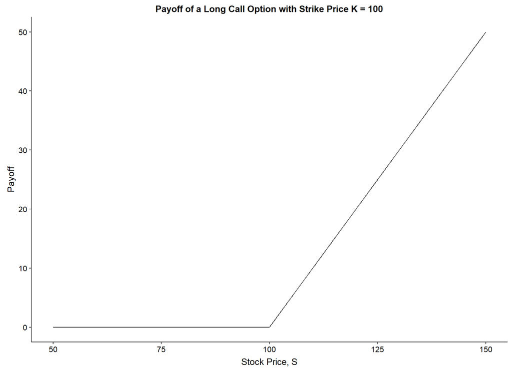

```r
S <- seq(50, 150, by = 0.1)
K <- 100

call_payoff <- pmax(S - K, 0);

ggplot() +
    geom_line(aes(x = S, y = call_payoff)) +
    xlab('Stock Price, S') +
    ylab('Payoff') +
    ggtitle('Payoff of a Long Call Option with Strike Price K = 100')
```

A put option is exactly the opposite: In the above scenario but with a put instead of a call, we have:

$$\text{Payoff} = \text{max}(0, 100 - S)$$

If the stock is at 105 USD the option is valueless as we only have the right to sell at 100 USD. When the stock is at 90 USD, we can buy the shares for 90, exercise the put and sell them for 100, netting 10 USD profit. Thus, the put is worth 10 USD.

```r
put_payoff  <- pmax(K - S, 0);

put_plot <- ggplot() +
    geom_line(aes(x = S, y = call_payoff)) +
    xlab('Stock Price, S') +
    ylab('Payoff') +
    ggtitle('Payoff of a Long Put Option with Strike Price K = 100')
```

Payoff curves are often overkill for simple options once you have a grasp of the basics, but are still a very useful tool for *option spreads*: combinations of different option contracts with the same underlying. We will not discuss spreads too much in this series as that is topic all in itself, but it is worth mentioning a few of the most common here as they are an excellent illustration of the use of payoff curves.

A *straddle spread* is the combination of a long (or short) call and put option with the same expiration and strike price. Straddle spreads tend to be used to trade volatility - the trader is betting on the size of the movement of the underlying rather than on the direction of the movement.

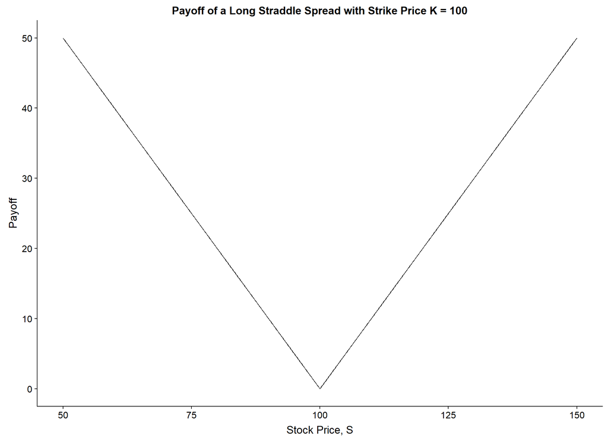

```r
ggplot() +
    geom_line(aes(x = S, y = call_payoff + put_payoff)) +
    xlab('Stock Price, S') +
    ylab('Payoff') +
    ggtitle('Payoff of a Long Straddle Spread with Strike Price K = 100')
```

A *call spread* is the combination of a long and short call option at different strikes[^12]. If the long strike is lower than the short strike, it is a *bullish* spread since it profits from a rise in stock price. If the short strike is lower, it is a *bearish* spread. In either case, the maximum profit is capped at the difference between the strikes.

```r
call1_payoff <- pmax(S - 100, 0)
call2_payoff <- pmax(S - 110, 0)

callspread_plot <- ggplot() +
    geom_line(aes(x = S, y = call1_payoff - call2_payoff)) +
    xlab('Stock Price, S') +
    ylab('Payoff') +
    ggtitle('Payoff of a 100/110 Bullish Call Spread')
```

## 2.2 Pricing Options

With the basics dealt with, we now start discussing the interesting parts of options: how to price them, and how their price depends on their inputs.

There are two main models for pricing options: the binomial model and the Black-Scholes model.

The binomial model uses a tree-like structure to model the price changes of the underlying over time, and has the advantage of making early-exercise features easy to implement. It is also computationally fast.

The Black-Scholes model is the workhorse of option pricing theory and results in the famous Black-Scholes partial differential equation for option prices:

$$\frac{dV}{dt} + \frac{1}{2} \sigma^2 S^2 \frac{d^2 V}{dS^2} + rS \frac{dV}{dS} - rV = 0$$

where $V$ is the price of the option, $S$ is the stock price, $r$ is the risk-free interest rate, $t$ is the time to expiration and $\sigma$ is the expected volatility of the underlying over the lifetime of the option.

Notice the absence of the strike price, $K$ in the equation. Why is this?

When solving the above equation, $K$ is important in setting boundary conditions for the solution, but the fact it is not in the equation itself is a manifestion of the close connection between the price of a call and a put.

We have mentioned the idea of volatility a few times now without actually explaining it. As its name suggests, volatility is a measure of the size of the relative moves of the underlying price.

Quantitative finance models price changes in assets in terms of percentage changes, termed the *returns* of the asset. This is for a number of reasons:

- Percentage changes are often easier to understand and remember when it comes to interpreting the output of models
- It allows more natural comparisons, without needing to know the underlying price level as a reference point, and allows comparisons across asset classes
- Much of quantitative finance deals with time series, and a sequence of percentage changes tends to behave more independently than a series of price changes, making it more amenable to statistical methods

A basic assumption of the Black-Scholes model is that returns of the underlying asset prices are distributed according to a lognormal distribution - the volatility of the asset is the standard deviation of this distribution.

Underlying assets that pay dividends can also be accounted for but we will keep things simple and assume no dividends are paid on the underlying.

All of the above inputs to the option pricing model are observable, with the exception of the volatility, $\sigma$, as we do not know the value of this quantity till after the option expires[^13].

We ignore the philosophical consequences of this, and focus on the most important practical one: we can use volatility and option price interchangeably. For a given set of observed values of $S$, $t$, $r$ and $K$, there is a one-to-one relationship between the option price and the volatility. Used this way, the volatility is called the *implied volatility* (or *implied vol* or *implied*). Thus, implied vols are proxies for option prices, and are independent of the current stock price.

In financial markets, volatility levels tend to be more stable than price levels, so traders quote option prices in terms of implieds[^14], plugging in the current stock value when executing the trade to get the dollar amount.

Before we move on to actual calculations, we have one more concept to discuss: units of time.

Markets in various asset classes are open from Monday to Friday. For equities, they open between the hours of 0930 to 1600. It often makes sense to measure time in terms of trading days rather than calendar days. Thus, years have 252 days in them (the approximate count of business days in a year).

As mentioned, volatility is a standard deviation and so scales by the square root of time.[^15] Thus, if we have a daily volatility of 1%, this becomes $\sqrt{252} = 15.8\%$ in annual terms. For simplicity, this factor is often rounded up to 16, meaning that an asset with an annualised volatility of 16% has a daily volatility of 1%.[^16]

The convention is to express volatility in annualised terms.

## 2.3 Calculating Option Prices

As mentioned in the previous post, there are many excellent books on option pricing, and I would not do it justice[^17]. Instead I want to focus on using R for this, and what we can learn from that.

We will use [QuantLib](http://www.quantlib.org), an extensive open-source library containing a cornucopia of useful functions for quantitative finance. It is available in R through the `RQuantLib` package - this is what we use for all subsequent work.

Suppose we have an American call option on a stock XYZ at price level 100 USD with a month to expiry (20 trading days) with 24% annualised volatility. How do we calculate a price for this option?

```r
interest_rate <- 0.01;

implied_vol <- 0.24
t           <- 20 / 252;
K           <- 100;

AmericanOption(type          = 'call'
              ,underlying    = 100
              ,strike        = K
              ,dividendYield = 0
              ,riskFreeRate  = interest_rate
              ,maturity      = t
              ,volatility    = implied_vol)
```

```
## Concise summary of valuation for AmericanOption
##  value  delta  gamma   vega  theta    rho divRho
## 2.7356     NA     NA     NA     NA     NA     NA
```

The other quantities, delta, gamma, vega, theta, rho and divRho are collectively known as the ‘Greeks’ and are the analytic derivatives of the price function with respect to the various parameters. They are termed such as they use Greek letters for their symbols, but also I suspect to avoid confusion from over-using the word ‘derivative’.

For some reason, QuantLib does not calculate the Greeks using the American option routines, so let us check what we get for European options:

```r
EuropeanOption(type          = 'call'
              ,underlying    = 100
              ,strike        = K
              ,dividendYield = 0
              ,riskFreeRate  = interest_rate
              ,maturity      = t
              ,volatility    = implied_vol)
```

```
## Concise summary of valuation for EuropeanOption
##    value    delta    gamma     vega    theta      rho   divRho
##   2.7356   0.5182   0.0589  11.2272 -17.4666   3.8952  -4.1123
```

The option price calculated is almost identical, and now we also have values for the Greeks. A quick finite difference calculation shows that the Greeks for the European options are equivalent to those for the equivalent American options, but we leave that as an exercise for the reader.

Now we look at the effect of underlying on the call price. We can check this by calculation this price for a sequence of prices and plotting the output. We plot this against the payoffs to get a sense of perspective for the price.

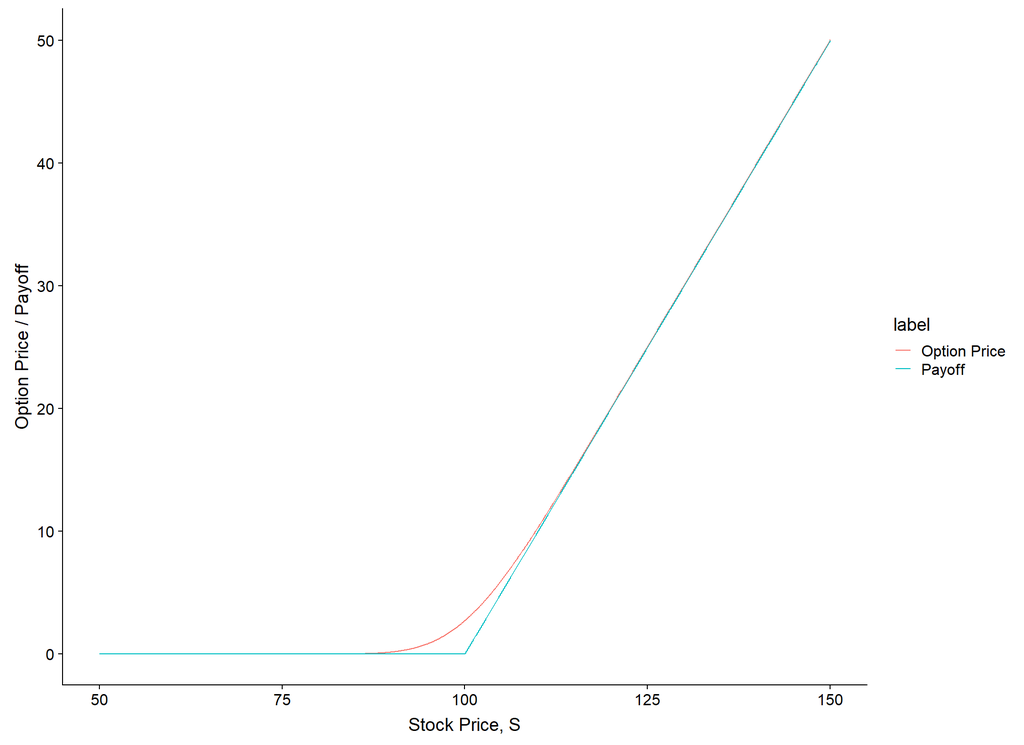

```r
S_seq <- seq(50, 150, by = 0.1)

call_payoff <- pmax(S_seq - K, 0)

price_seq <- sapply(S_seq, function(iterS)
    AmericanOption(type          = 'call'
                  ,underlying    = iterS
                  ,strike        = K
                  ,dividendYield = 0
                  ,riskFreeRate  = interest_rate
                  ,maturity      = t
                  ,volatility    = implied_vol)$value)

plot_dt <- rbind(tibble(label = 'Option Price', S_seq = S_seq, value = price_seq)
                ,tibble(label = 'Payoff',       S_seq = S_seq, value = call_payoff)
                )


ggplot(data = plot_dt) +
    geom_line(aes(x = S_seq, y = value, colour = label)) +
    xlab("Stock Price, S") +
    ylab("Option Price / Payoff")
```

#### 2.3.0.1 Option Intrinsic Value and Option Time Value

Option prices can be split into two components, the *intrinsic value* - the value of the option were it to be immediately exercised - and the *time value* of the option which is the remainder. The time value is also referred to as the *option premium*.

Options that are in the money always have positive intrinsic value. Options that are out of the money only have premium in them.

If we look at a zoomed-in version of the previous plot, we can see how the premium behaves as the underlying changes. We will discuss this further when we talk about the Greeks, but visuals will work for now.

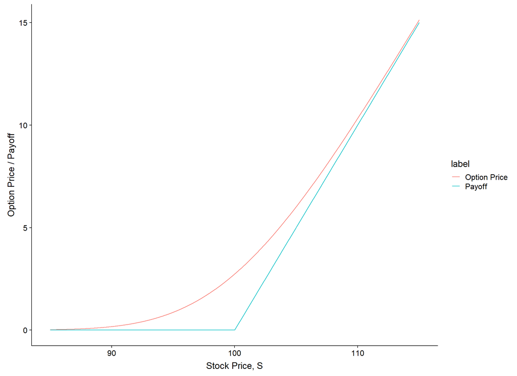

Looking at the plot, we see the premium increases as the underlying approaches the strike price. At the strike price, the premium is at its maximum, and beyond that the intrinsic value becomes non-zero and takes an increasing proportion of the option value.

### 2.3.1 Comparing Calls and Puts

We mentioned earlier that there is a relationship between the price of a call and a put for a given set of parameters. This relationship, put/call parity, can be expressed in closed form for European options:

$$C = P + S - K e^{-rt}$$

Let us investigate this by calculating calls and puts with strike price $K = 100$, for $S = 90, 100, 110$, starting with $S = 90$:

```r
### Comparison of call and put prices

interest.rate <- 0.01

implied.vol <- 0.24
t           <- 20 / 252
K           <- 100

# Calls
call_090 <- EuropeanOption(type = 'call'
                          ,underlying    = 90
                          ,strike        = K
                          ,dividendYield = 0
                          ,riskFreeRate  = interest.rate
                          ,maturity      = t
                          ,volatility    = implied.vol)

call_100 <- EuropeanOption(type = 'call'
                          ,underlying    = 100
                          ,strike        = K
                          ,dividendYield = 0
                          ,riskFreeRate  = interest.rate
                          ,maturity      = t
                          ,volatility    = implied.vol)

call_110 <- EuropeanOption(type = 'call'
                          ,underlying    = 110
                          ,strike        = K
                          ,dividendYield = 0
                          ,riskFreeRate  = interest.rate
                          ,maturity      = t
                          ,volatility    = implied.vol)

# Puts
put_090 <- EuropeanOption(type = 'put'
                         ,underlying    = 90
                         ,strike        = K
                         ,dividendYield = 0
                         ,riskFreeRate  = interest.rate
                         ,maturity      = t
                         ,volatility    = implied.vol)

put_100 <- EuropeanOption(type = 'put'
                         ,underlying    = 100
                         ,strike        = K
                         ,dividendYield = 0
                         ,riskFreeRate  = interest.rate
                         ,maturity      = t
                         ,volatility    = implied.vol)

put_110 <- EuropeanOption(type = 'put'
                         ,underlying    = 110
                         ,strike        = K
                         ,dividendYield = 0
                         ,riskFreeRate  = interest.rate
                         ,maturity      = t
                         ,volatility    = implied.vol)
```

```
## Put price for S = 90
```

```
## Concise summary of valuation for EuropeanOption
##   value   delta   gamma    vega   theta     rho  divRho
## 10.0894 -0.9348  0.0209  3.2212 -3.9284 -7.4780  6.6772
```

```
## Call price for S = 90
```

```
## Concise summary of valuation for EuropeanOption
##   value   delta   gamma    vega   theta     rho  divRho
##  0.1688  0.0652  0.0209  3.2212 -4.9276  0.4521 -0.4655
```

A quick inspection of the numbers shows that gamma and vega are the same, and $\Delta\_C - 1 = \Delta\_P$. This will make sense once we have discussed the Greeks.

Moving on to $S = 100$:

```
## Put price for S = 100
```

```
## Concise summary of valuation for EuropeanOption
##    value    delta    gamma     vega    theta      rho   divRho
##   2.6563  -0.4818   0.0589  11.2272 -16.4674  -4.0348   3.8240
```

```
## Call price for S = 100
```

```
## Concise summary of valuation for EuropeanOption
##    value    delta    gamma     vega    theta      rho   divRho
##   2.7356   0.5182   0.0589  11.2272 -17.4666   3.8952  -4.1123
```

Finally, we look at $S = 110$. Given the symmetry, it would not be too surprising to see a similar result for $S = 90$ but with calls and puts switched:

```
## Put price for S = 110
```

```
## Concise summary of valuation for EuropeanOption
##   value   delta   gamma    vega   theta     rho  divRho
##  0.2478 -0.0728  0.0186  4.2882 -6.4013 -0.6553  0.6356
```

```
## Call price for S = 110
```

```
## Concise summary of valuation for EuropeanOption
##   value   delta   gamma    vega   theta     rho  divRho
## 10.3271  0.9272  0.0186  4.2882 -7.4005  7.2748 -8.0944
```

This asymmetry arises as a consequence of the assumptions in Black-Scholes model. The asset is assumed to move according to a lognormal distribution. The volatility is the standard deviation of this distribution, but the mean is not zero, it is slightly positive due to the risk free rate. As a result there is a slight bias upwards in the price movements. Hence the higher premium on the upside prices for $S$.[^18]

We will discuss this further once we have an understanding of the Greeks.

## 2.4 The First and Second Derivatives - The ‘Greeks’

Every discussion of option pricing involves describing the ‘Greeks’ - derivatives of the option price with respect to different input quantities such as stock price and volatility.

### 2.4.1 Delta: $\Delta = \frac{dV}{dS}$

The delta, $\Delta$, of an option is the first derivative of the option price with respect to underlying price. It can be interpreted in two ways:

- it is the equivalent amount of shares the option corresponds to at this instant. Being long a 30-delta call option is equivalent to owning 30 shares of the underlying.
- the absolute value of the delta is the probability of that option ending up being in the money

Numerically, delta varies from -1 to 1, but as option contracts are for 100 shares, we generally multiply the delta by 100. Historically, this made it simpler for traders to know their exact exposure to the underlying stock in terms of shares. Also, the human brain finds it easier to think in terms of whole numbers than with decimals.

Calls have a positive delta as they are a bullish instrument and so are like being long the underlying, whereas puts are bearish and so have negative deltas.

At the money options have absolute delta values close to 50. The strike that is the closest will have deltas closest to 50.

Conversely, options where the delta is close to 100 or -100 behave like the underlying and are often treated as such for risk management purposes.

One counter-intuitive result of using options is that deltas tend to be simultaneously the most important Greek from a risk point of view while being the least interesting from a trading and portfolio management point of view.

### 2.4.2 Gamma: $\Gamma = \frac{d^2V}{dS^2}$

The Gamma, $\Gamma$, of an option is the second derivative of the price with respect to the underlying price - it describes the change in delta as the underlying changes.

Similar to delta values, gamma values are multiplied by 100 when quoted, and represent the instantaneous change in delta when the underlying moves by 1 USD.

Gamma is hugely important for options and holds a similar position to convexity in bond pricing. Its existence is one of the reasons why the behaviour of option prices can be counter-intuitive - the presence of a non-zero second derivative causes non-linear behaviour.

To see the importance of gamma, suppose we have a straddle spread where the strike of the spread is at the money. Such a spread has almost no delta but a lot of gamma. This means that while the delta of the spread is zero right now, it is likely to change significantly as the underlying price moves.

The gamma of an option is positive for both calls and puts.

### 2.4.3 Vega: $\text{Vega} = \frac{dV}{d\sigma}$

The vega of an option is the first derivative of the option price with respect to the implied volatility.

It is quoted in units of dollar amounts and is scaled to represent the change in value of an option when the implied vol moves by 1 ‘vol click’ i.e. when the vol moves from 24% to 25%.

The RQuantLib functions calculate vega on the scale of changes of 1 unit of vol, 100 vol clicks, so this needs to be accounted for.

The vega of an option is always positive.

### 2.4.4 Theta: $\Theta = \frac{dV}{dt}$

The theta, $\Theta$, of an option is the first derivative of the price with respect to time.

For practical reasons it is usually expressed in terms of change in price per day, requiring a transformation of the output of the QuantLib routines as the default amount is the same unit of time for the maturity and volatility (usually annualised in years).

Theta represents the passive change in option price if nothing else changes. It is always negative as option values decay as time passes. This is because the reduced lifetime of the options results in less opportunity for the underlying to move, and thus is worth less.

### 2.4.5 Rho: $\rho = \frac{dV}{dt}$

The Rho, $\rho$, of an option is the first derivative of the option price with respect to interest rate.

This also needs the QuantLib output to be modified as it is more natural to think in terms of change in price per change in interest rate points (100 basis points).

Interest rate moves tend to be well signposted and most option trading tends to be for short timescales, so rho is not as important for most use cases as its effect is limited. It can be extremely important for very long-dated options though.

## 2.5 Summary

In this article we introduced payoff graphs and looked at the charts for some option spreads. We also used the QuantLib library in R through the `RQuantLib` package to calculate option prices.

Finally, we introduced the Greeks and talked a little about why they are important.

In the next article, we will continue this discussion and show how calls and puts behave similarly. We will also talk a little about the consequences of the non-linearity in options.

# 3 Third Post

In the first two articles of this series we discussed various aspects of options and options trading, necessary background for the real meat of the series: how do options behave under various circumstances, and what implications do these behaviours have in their use?

In this article we will start that exploration, but we will only have time to scratch the surface: there is much more content than we have time for in this series so we will look at a few different things, perhaps suggest a few more avenues of investigation, and try to bring it all together in the fourth and final post of this series.

Most of my personal experience with options is for equitiess and exchange-traded funds (ETFs) - a financial instrument that closely tracks an underlying index - but behaves in most repects like equity. There are options on other instruments: bonds, futures, currencies for example, and while there are subtle differences between these options that are crucial to understand when trading them, they behave in similar ways for our purposes.

To help clarity, we focus on options on equities and equity ETFs but bear in mind that many of these behaviours translate to all options.

For the first few sections we hold volatility constant: a huge and unrealistic simplification. The behaviour of implied volatility is a major component of option trading, so we will discuss it in the final article. Things are complex enough with vol constant.

Finally, we focus almost entirely on options with a shorter expiration, in most cases 40 trading days or less. The majority of trading liquidity in options is short-term focused, and though there are exchange-traded options with longer expirations (out to a few years in some cases), we will ignore these for the main.

In quite a few cases, some behaviours dicussed do not hold for all options, especially for options with longer expirations, so beware!

## 3.1 Units of Greeks Redux

We also recall that options are traded as contracts for 100 shares, but are priced in respect to a single share. In most cases we can ignore this point and focus on options as if they were for a single share, but it may be prudent to point it out at times. We also will discuss the Greeks as a contract for consistency with convention, so we quote the deltas and gammas in terms of contracts and multiply them by 100 in general. We will take note of this distinction when it becomes relevant.

Despite this convention for deltas and gammas, vega and theta is quoted on a per-share basis. This is likely due to both vega and theta are in units of currency, so the quoting convention is more natural here.

Similarly, theta is quoted in time units of one day, so if an option with 10 trading days remaining is worth 2 USD and has a theta of -0.20, we expect the price at the same time tomorrow to be about 1.80 USD.

We also largely ignore interest-rate effects on pricing as we focus on more short term maturities of two months or less - 40 trading days.

## 3.2 Revisiting Put-Call Parity

We have discussed a few times in previous posts the close relationship between the price of a call and put option. For future brevity, we will introduce one more piece of terminology in options - the *line*, a specific combination of expiration and strike price. Historically, option prices were quoted in expiration and strike order, with the strike prices in a column down the centre.

The reason for this close relationship is somewhat counterintuitive: from an optionality point of view, call and put options are the same - that is, the only difference between between a call and put option is 100 deltas. This is exactly true for European options but still holds approximately for American options.

This seems quite the claim so let us at least check this. We will take a series of values for stock price, strike price, volatility etc, calculate the various option prices, and see how they compare.

```r
S_vals    <- seq(25, 100, by = 25)
K_vals    <- seq(25, 100, by = 25)
vol_vals  <- seq(0.1, 0.5, by = 0.1)
r_vals    <- c(0.01, 0.02, 0.05, 0.10)
T_vals    <- c(5, 10, 20, 60, 120, 252) / 252

params_dt <- CJ(S = S_vals, K = K_vals, vol = vol_vals, r = r_vals, T = T_vals)
params_dt[, contract_id := .I]

calc_option_price <- function(type, S, K, r, t, vol) {
    dS <- S * 1e-6
    dt <- t * 1e-6
    do <- vol * 1e-6

    V <- AmericanOption(type          = type
                       ,underlying    = S
                       ,strike        = K
                       ,dividendYield = 0
                       ,riskFreeRate  = r
                       ,maturity      = t
                       ,volatility    = vol)$value

    VpdS <- AmericanOption(type          = type
                          ,underlying    = S + dS
                          ,strike        = K
                          ,dividendYield = 0
                          ,riskFreeRate  = r
                          ,maturity      = t
                          ,volatility    = vol)$value

    VmdS <- AmericanOption(type          = type
                          ,underlying    = S - dS
                          ,strike        = K
                          ,dividendYield = 0
                          ,riskFreeRate  = r
                          ,maturity      = t
                          ,volatility    = vol)$value

    Vpdt <- AmericanOption(type          = type
                          ,underlying    = S
                          ,strike        = K
                          ,dividendYield = 0
                          ,riskFreeRate  = r
                          ,maturity      = t + dt
                          ,volatility    = vol)$value

    Vmdt <- AmericanOption(type          = type
                          ,underlying    = S
                          ,strike        = K
                          ,dividendYield = 0
                          ,riskFreeRate  = r
                          ,maturity      = t - dt
                          ,volatility    = vol)$value

    Vpdo <- AmericanOption(type          = type
                          ,underlying    = S
                          ,strike        = K
                          ,dividendYield = 0
                          ,riskFreeRate  = r
                          ,maturity      = t
                          ,volatility    = vol + do)$value

    Vmdo <- AmericanOption(type          = type
                          ,underlying    = S
                          ,strike        = K
                          ,dividendYield = 0
                          ,riskFreeRate  = r
                          ,maturity      = t
                          ,volatility    = vol - do)$value

    delta <- (VpdS - VmdS) / (2 * dS)
    gamma <- (VpdS - 2 * V + VmdS) / (dS^2)
    vega  <- (Vpdo - Vmdo) / (2 * do)
    theta <- (Vpdt - Vmdt) / (2 *dt)

    return(c(price = V
            ,delta = delta * 100
            ,gamma = gamma * 100
            ,vega  = vega * 0.01
            ,theta = theta / 252))
}

call_dt <- params_dt[, data.table(t(mapply(calc_option_price, 'call', S, K, r, T, vol)))]
put_dt  <- params_dt[, data.table(t(mapply(calc_option_price, 'put',  S, K, r, T, vol)))]

data_dt <- rbind(cbind(type = 'call', params_dt, call_dt)
                ,cbind(type = 'put',  params_dt, put_dt))

data_dt <- dcast(data_dt, contract_id + S + K + r + T + vol ~ type
                ,value.var = c("price", "delta", "gamma", "vega", "theta"))

compare_dt <- data_dt[, .(contract_id, price_call, price_put
                         ,S, K, r, T, vol
                         ,d_delta = delta_call - delta_put
                         ,d_gamma = gamma_call - gamma_put
                         ,d_vega  = vega_call  - vega_put
                         ,d_theta = theta_call - theta_put)]

print(compare_dt[, .(S, K, T = round(T, 4), vol, d_delta, d_gamma, d_vega, d_theta)])
```

```
##         S   K      T vol d_delta    d_gamma       d_vega    d_theta
##    1:  25  25 0.0198 0.1 100.057 -0.2316192  5.90552e-06 0.00000000
##    2:  25  25 0.0397 0.1 100.095 -0.2750289  1.37522e-05 0.00000000
##    3:  25  25 0.0794 0.1 100.159 -0.3283418  3.12908e-05 0.00000000
##    4:  25  25 0.2381 0.1 100.363 -0.4432632  1.11699e-04 0.00000000
##    5:  25  25 0.4762 0.1 100.614 -0.5412559  2.34991e-04 0.00184625
##   ---
## 1916: 100 100 0.0397 0.5 100.284 -0.0431610 -1.80811e-04 0.00000000
## 1917: 100 100 0.0794 0.5 100.488 -0.0535039  2.19685e-04 0.00000000
## 1918: 100 100 0.2381 0.5 101.163 -0.0782130  2.99882e-04 0.00000000
## 1919: 100 100 0.4762 0.5 102.012 -0.1015010 -5.75354e-04 0.06584036
## 1920: 100 100 1.0000 0.5 103.585 -0.1361755 -6.01381e-03 0.02846683
```

From what we can see, it appears that this statement is holding. The theta differences are not hugely suprising as it is the amount of value decay due to time, and it makes sense that the higher price contract would have a higher value: it has more value to decay.

We can quickly check this data for differences:

```r
compare_dt[abs(d_delta - 100) > 1 | abs(d_gamma) > 1 | abs(d_vega) > 0.01]
```

```
##      contract_id price_call price_put   S   K    r         T vol d_delta
##   1:           6   1.121309  0.890916  25  25 0.01 1.0000000 0.1 101.079
##   2:          10   0.547146  0.436552  25  25 0.02 0.2380952 0.1 100.999
##   3:          11   0.809835  0.591811  25  25 0.02 0.4761905 0.1 101.674
##   4:          12   1.254245  0.805035  25  25 0.02 1.0000000 0.1 102.895
##   5:          13   0.153153  0.129796  25  25 0.05 0.0198413 0.1 100.601
##  ---
## 268:        1896  20.318469 12.024390 100 100 0.10 1.0000000 0.4 104.585
## 269:        1914  21.792604 17.468477 100 100 0.05 1.0000000 0.5 101.426
## 270:        1918  10.816703  8.666760 100 100 0.10 0.2380952 0.5 101.163
## 271:        1919  15.829441 11.676014 100 100 0.10 0.4761905 0.5 102.012
## 272:        1920  23.926745 15.690441 100 100 0.10 1.0000000 0.5 103.585
##        d_gamma       d_vega     d_theta
##   1: -0.677325  4.68145e-04 0.000860183
##   2: -1.260565  2.67732e-04 0.000000000
##   3: -1.547367  4.98756e-04 0.003595708
##   4: -1.944205  7.56843e-04 0.001669765
##   5: -2.549672  5.77016e-05 0.000000000
##  ---
## 268: -0.217870 -5.62447e-03 0.029021897
## 269: -0.051088 -2.16932e-03 0.015316502
## 270: -0.078213  2.99882e-04 0.000000000
## 271: -0.101501 -5.75354e-04 0.065840359
## 272: -0.136176 -6.01381e-03 0.028466826
```

Numerical rounding and precision is an issue in the calculations of the Greeks here, but we can see that broadly speaking, there is almost no difference between any of the Greeks along a line.

What is the consequence of this?

Simply stated, it means that being long 1 call contract (for 100 shares) and short 100 shares gives the same profit and loss (PnL for short) as being long 1 put contract. Conversely, being long 1 put and long 100 shares is the same as being long 1 call contract.

To check this, we start with an option with a strike price of 100 with a volatility of 20%. Suppose we are 40 days out and the underlying stock is at 95. We buy the 100 call (the call option at the 100 strike), paying the price. Suppose after one day’s trading the underlying has moved up to 100. What is the PnL in this case, and how does it compare to being long the 100 put and long the stock instead?

If our previous assertion is correct, they are the same.

```r
create_line_pricer <- function(K, r, vol) {
    calc_prices <- function(S, t) {
        call_price <- AmericanOption(type          = 'call'
                                    ,underlying    = S
                                    ,strike        = K
                                    ,dividendYield = 0
                                    ,riskFreeRate  = r
                                    ,maturity      = t
                                    ,volatility    = vol)$value

        put_price  <- AmericanOption(type          = 'put'
                                    ,underlying    = S
                                    ,strike        = K
                                    ,dividendYield = 0
                                    ,riskFreeRate  = r
                                    ,maturity      = t
                                    ,volatility    = vol)$value

        return(c(c = call_price, p = put_price))
    }

    return(calc_prices)
}

K   <- 100
r   <- 0.01
vol <- 0.20

option_pricer <- create_line_pricer(K = K, r = r, vol = vol)
```

I have created a little utility function `option_pricer` which calculates the call and put price with the above parameters for a given underlying price and time.

```r
op_day1 <- option_pricer(S = 95,  t = 40/252)
op_day2 <- option_pricer(S = 100, t = 39/252)

pnl_call     <- (op_day2['c'] - op_day1['c'])
pnl_putstock <- (op_day2['p'] - op_day1['p']) + (100 - 95)

print(op_day1, digits = 5)
```

```
##      c      p
## 1.2585 6.1141
```

```r
print(op_day2, digits = 5)
```

```
##      c      p
## 3.2135 3.0645
```

```r
print(c(pnl_call, pnl_putstock), digits = 5)
```

```
##      c      p
## 1.9551 1.9504
```

It is worth spending a little time unpicking all this as there are a few things to consider. These calculations should be exact but may not be due to rounding. Discrepancies will be small.

We start with the calculation for the call.

On day 1, 40 days to expiration, the call is worth about 1.25 USD and the stock is at 95 USD. We buy the call, so our account has a 100 call and a negative cash balance of -1.25 USD, the price we paid for the call.

After one day, the stock moved up to 100 USD, and we need to recalculate the price of the call for the new stock price and time to maturity. We also need to account for the interest rate charge on the cash balance. It will be small, but is important to remember. For trading operations, interest rate charges and fees are a significant aspect of the business and need attention.

As a quick exercise, without looking below, will the move in the underlying result in a profit or loss in the call and by how much? The answer may seem obvious, but it is not.

The new value is 3.22 USD, so our profit is

$$3.22 - 1.25 = 1.97$$

Assuming liquid markets, this profit is more than just a paper profit - we could sell the call and take the profit if we wished.

Now we look at the PnL for a put and a share.

On day 1 the put is worth 6.11. Note that we could split this price into 5 USD of intrinsic value - the put is 5 USD in the money - and 1.11 USD of option premium. We pay 6.11 for the put, and we buy a share for 95 USD. Thus, we now have a long 100 put, a share of the stock, and a cash balance of -101.11, the sum of the cost of the put and the share.

After day 2, the stock has moved up to 100, so what is our PnL?

The new value for the put is 3.07, so the profit from that is

$$3.07 - 6.11 = -3.04$$

The put has lost value, but we are also long a share, which has gained in value by 5 USD. Our total profit is

$$(3.07 - 6.11) + (100 - 95) = 1.9610$$

Quite a narrow disparity, but we have forgotten to include interest on the cash balances. Does this have much effect?

For the long call we have a negative cash balance of 1.25 USD and so pay interest for one day on this. For the long put and stock, it is negative 101.11, so we check the difference in these charges.

```r
intrate_call     <- (op_day1['c']     ) * (exp(-r * 1/252) - 1)
intrate_putstock <- (op_day1['p'] + 95) * (exp(-r * 1/252) - 1)

print(c(intrate_call, intrate_putstock), digits = 5)
```

```
##           c           p
## -4.9938e-05 -4.0124e-03
```

```r
print(c(pnl_call + intrate_call, pnl_putstock + intrate_putstock), digits = 5)
```

```
##      c      p
## 1.9550 1.9464
```

Even allowing for interest charges, the discrepancy due to the options being American is narrow enough to be ignored for our purposes.

As one final check, let us see what happens if we used a straddle in the above scenario, and then replace the call with the put and stock. Recall that a straddle spread is a call and a put on the same line. We compare this to a having two puts and being long a share.

```r
### The straddle is the sum of the prices
pnl_straddle <- sum(op_day2) - sum(op_day1)

### Switch the call for a put and a share, so 2 puts 1 share
pnl_2putshare <- 2 * (op_day2['p'] - op_day1['p']) + (100 - 95)

print(c(pnl_straddle, pnl_2putshare))
```

```
##                 p
## -1.09450 -1.09918
```

This explains why all the Greeks for a call and put on the same line are the same apart from the delta (which differs by 100). Price parity forces this to be the case.[^20]

## 3.3 Option Premium Decay

We discovered in the last article that theta for an option is negative: that is, as time passes the value of an option decreases. This makes sense, option premium is an expectation of future possible value and as time passes there is less opportunity for the stock to move and realise that value. How does this decay happen? Is it gradual and linear, exponential? Before looking below, think about what may make sense.

Suppose we an 40-day at-the-money option with 20% volatility and underlying/strike of 100. We can calculate the value of this option over time, using the unrealistic assumption that nothing else will change.

### 3.3.1 Time Decay for At-the-Money Options

We start with at-the-money options as they are usually the most interesting. We do a plot from 40 days out to expiration, and hold all other inputs constant. The intrinsic value of the option is zero throughout, so the price decreases to zero at expiration.

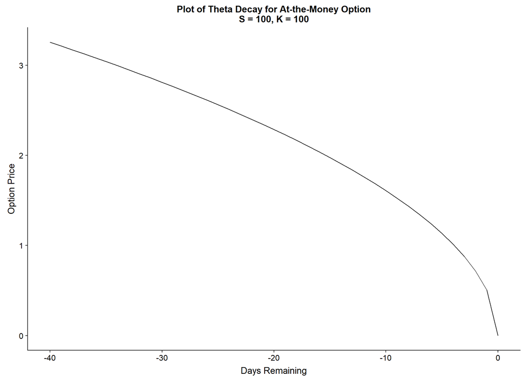

```r
days_remaining <- seq(40, 0, by = -1)

S <- 100
K <- 100

option_pricer <- create_line_pricer(K = K, r = r, vol = vol)

decay_atm_price <- sapply(days_remaining / 252, function(iterT) option_pricer(S, iterT)['c'])

ggplot() +
    geom_line(aes(x = -days_remaining, y = decay_atm_price)) +
    expand_limits(y = 0) +
    xlab("Days Remaining") +
    ylab("Option Price") +
    ggtitle("Plot of Theta Decay for At-the-Money Option\nS = 100, K = 100")
```

The decay is slow at the beginning, approximating a constant decay, accelerating towards zero in the last 5-10 days of lifetime. The option sustains its value as there is a large probability of the option expiring in the money right up to expiration, the decay reflects the fact that it takes time for the underlying to move, and so shorter lifetimes reduce the variance of this distribution of prices of the underlying at expiration, in turn reducing the value of the option.

### 3.3.2 Time Decay for Out-of-the-Money Options

OTM options also have zero intrinsic value throughout its lifetime, but also have a distance to cross before they are in the money. We would expect the option prices to be lower than at-the-money options.

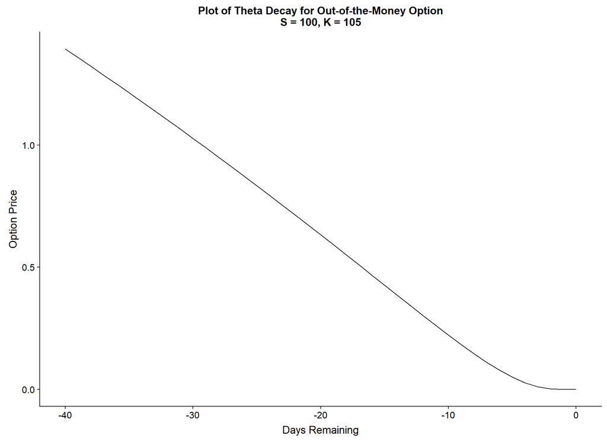

```r
S <- 100
K <- 105

option_pricer <- create_line_pricer(K = K, r = r, vol = vol)

decay_otm_price <- sapply(days_remaining / 252, function(iterT) option_pricer(S, iterT)['c'])

ggplot() +
    geom_line(aes(x = -days_remaining, y = decay_otm_price)) +
    expand_limits(y = 0) +
    xlab("Days Remaining") +
    ylab("Option Price") +
    ggtitle("Plot of Theta Decay for Out-of-the-Money Option\nS = 100, K = 105")
```

Similar to the ATM case, the option value decay approximates a constant rate, but loses almost all value earlier than the ATM option. In terms of distributions of possible outcomes, a positive payoff for the option requires us to go further into the right tail as time passes. This reduction in expectation implies a low price for the option with days left before expiration.

### 3.3.3 Time Decay for In-the-Money Options

For ITM options, the intrinsic value of the option is positive, so the price decays to this value at expiration, as we see in the plot.

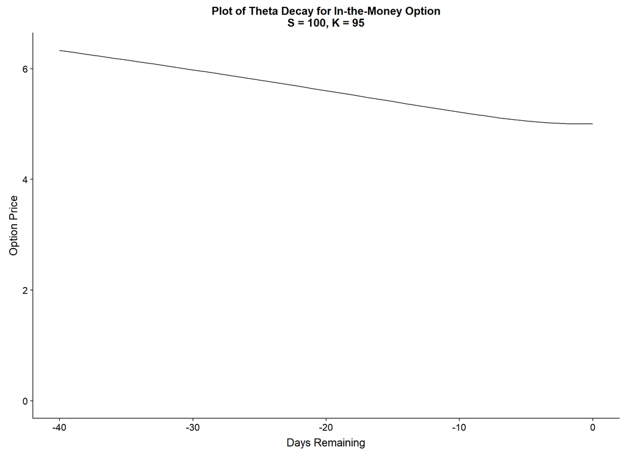

```r
S <- 100
K <-  95

option_pricer <- create_line_pricer(K = K, r = r, vol = vol)

decay_itm_price <- sapply(days_remaining / 252, function(iterT) option_pricer(S, iterT)['c'])

decay_itm_price[length(decay_itm_price)] <- S - K

ggplot() +
    geom_line(aes(x = -days_remaining, y = decay_itm_price)) +
    expand_limits(y = 0) +
    xlab("Days Remaining") +
    ylab("Option Price") +
    ggtitle("Plot of Theta Decay for In-the-Money Option\nS = 100, K = 95")
```

If we remove the intrinsic value and focus solely on the premium in the ITM option, how does this behave? We will draw all three plots together.

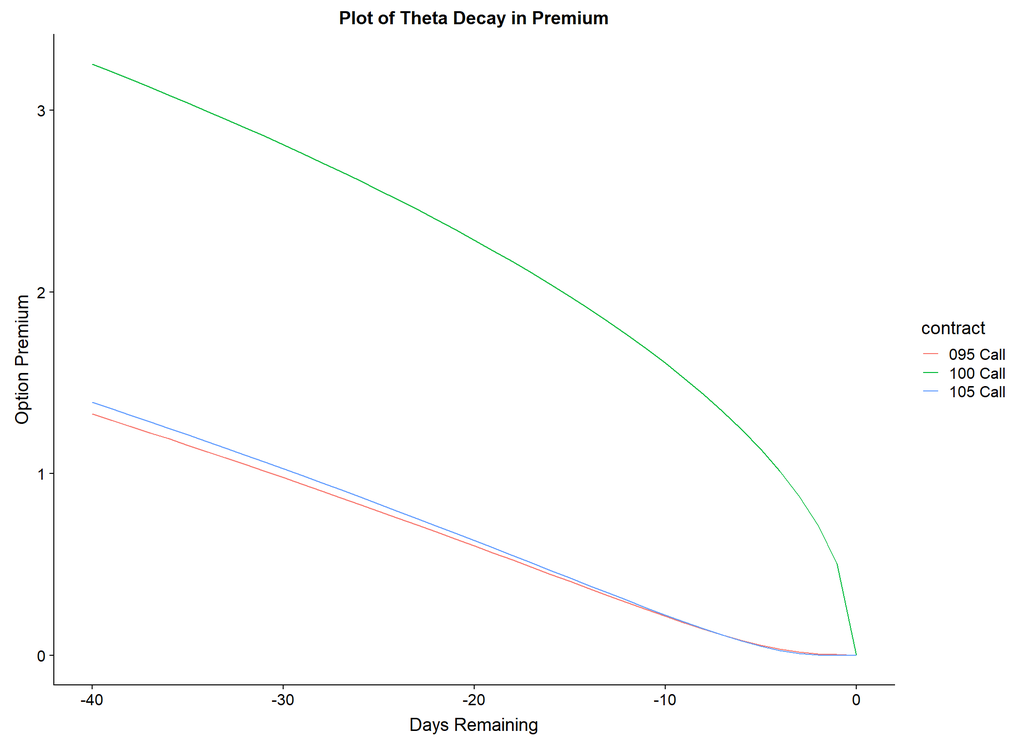

This plot was surprising, and confirmed something suggested at by the earlier plots: the premium decay for ITM and OTM options are very similar. Note that the ITM and OTM options are 5 USD from the underlying of 100.

When viewed in terms of put-call parity, it makes sense: the premium in the ITM call is similar to the premium in the put from the same line. The 105 Put will decay in a very similar way to the 95 Call. We can check this:

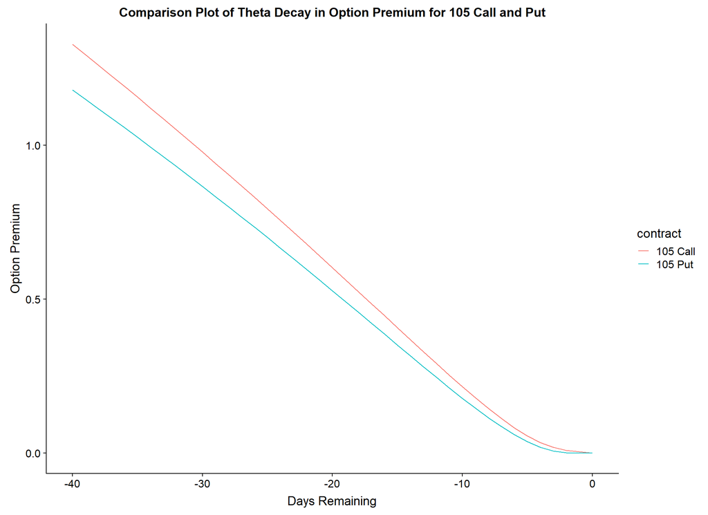

```r
S <- 100
K <-  95

option_pricer <- create_line_pricer(K = K, r = r, vol = vol)

decay_105Put_price <- sapply(days_remaining / 252, function(iterT) option_pricer(S, iterT)['p'])

plot_dt <- rbind(data.table(contract = '105 Call', days = -days_remaining, premium = decay_itm_price - 5)
                ,data.table(contract = '105 Put',  days = -days_remaining, premium = decay_105Put_price)
                )

ggplot(data = plot_dt) +
    geom_line(aes(x = days, y = premium, colour = contract)) +
    expand_limits(y = 0) +
    xlab("Days Remaining") +
    ylab("Option Premium") +
    ggtitle("Comparison Plot of Theta Decay in Option Premium for 105 Call and Put")
```

The slightly larger premium in the call over the put is the positive expected drift in the share price over time due to the risk-free interest rate.

### 3.3.4 Consequences of Theta Decay

An immediate consequence of the time decay of premium is that owning options is expensive. As each day passes, more and more of the value of your portfolio erodes away, and this is difficult from a psychological point of view. If you are long options, the stock has to move in your favour at least as much as your decay or you will suffer a loss in your account.

This makes trading long option positions complicated: it often requires active trading, the success of which is heavily dependent on making good estimates of the short term direction of the market - a difficult task. This will become more apparent in the next section when we discuss how Gamma works.

## 3.4 Gamma, Vega and Nonlinear Behaviour

It is becoming apparent how complex option behaviour can be. Options are non-linear instruments, and this nonlinearity results in behaviour that is not intuitive and surprising.

The Gamma of an option is the second derivative of the option price with respect to the price of the underlying. It gives us the instantaneous rate of change of delta as the underlying price changes. For example, suppose we are long a 30 delta call. The gamma of the option is 10. This means if the stock price goes up, the delta of the call will be around 40. Long option positions are always long gamma.

As an exercise for how all this works, we ponder another question. Suppose we have a 100 call and the stock is at 95, we are 20 days from expiration, the volatility is 20%. We will use European options for this, purely because QuantLib gives use the Greeks automatically. The price and Greeks for this options is as follows:

```r
calc_price_greeks <- function(...) {
    option_price <- EuropeanOption(...)

    option_price$delta <- option_price$delta * 100
    option_price$gamma <- option_price$gamma * 100
    option_price$vega  <- option_price$vega  * 0.01
    option_price$theta <- option_price$theta/252

    return(unlist(option_price[c('value','delta','gamma','vega','theta')]))
}


price_greeks <- calc_price_greeks(type          = 'call'
                                 ,underlying    = 95
                                 ,strike        = 100
                                 ,riskFreeRate  = 0.01
                                 ,maturity      = 20/252
                                 ,dividendYield = 0
                                 ,volatility    = 0.20)

print(price_greeks)
```

```
##     value     delta     gamma      vega     theta
##  0.554937 19.266490  5.113260  0.073248 -0.037329
```

We are long a 20 delta call 5 USD from the money, and the gamma is about 5. If the stock price goes up 1 USD in a short period of time (so we do not have to modify the time to maturity), what happens?

We will calculate it and see, but before that, it is worth making some educated guesses. It will help develop our intuition for this.

The delta of the option is positive, so we are long deltas. This means the option gains value from a rising share price, so we expect the stock price to go up. We are also long gamma though, gamma is positive, so this means that as the stock price goes up, the delta of the option also goes up. Thus, there is an acceleration in the increase in the price, so the over small increases at least, we expect the increase in option value to be larger than that implied by the delta.

We are just trying to get a sense for this, so we could split the difference and expect the new value of the option to be worth about 0.79 USD.

Let us see how accurate we are:

```r
price_greeks_up <- calc_price_greeks(type          = 'call'
                                    ,underlying    = 96
                                    ,strike        = 100
                                    ,riskFreeRate  = 0.01
                                    ,maturity      = 20/252
                                    ,dividendYield = 0
                                    ,volatility    = 0.20)

print(price_greeks_up)
```

```
##      value      delta      gamma       vega      theta
##  0.7744270 24.7534498  5.8441130  0.0854892 -0.0436578
```

Not too bad for a quick calculation! We got the price about right, as we did the delta. Note that the gamma has also increased, so further increases in share price will accelerate the gains in option price further.

What would happen if the price had gone down by 1 USD instead of up?

As we are long deltas, a fall in share price reduces the price of the option, and the positive gamma means that the delta also decreases. In this scenario, this is a good thing - a falling share price means a falling delta slows down the decrease in value. Our intuition might also suggest that the new value for gamma will be lower.

```r
price_greeks_dn <- calc_price_greeks(type          = 'call'
                                    ,underlying    = 94
                                    ,strike        = 100
                                    ,riskFreeRate  = 0.01
                                    ,maturity      = 20/252
                                    ,dividendYield = 0
                                    ,volatility    = 0.20)

print(price_greeks_dn)
```

```
##      value      delta      gamma       vega      theta
##  0.3865224 14.5499266  4.3134398  0.0604964 -0.0307762
```

### 3.4.1 Time Effects

```r
price_greeks_time <- calc_price_greeks(type          = 'call'
                                      ,underlying    = 96
                                      ,strike        = 100
                                      ,riskFreeRate  = 0.01
                                      ,maturity      = 19/252
                                      ,dividendYield = 0
                                      ,volatility    = 0.20)

print(price_greeks)
```

```
##     value     delta     gamma      vega     theta
##  0.554937 19.266490  5.113260  0.073248 -0.037329
```

```r
print(price_greeks_time)
```

```
##      value      delta      gamma       vega      theta
##  0.7305279 24.1289765  5.9139348  0.0821853 -0.0441464
```

In the first instance, we still had 20 days left in the option, but in this new case, we have 19 days. As there is less time for the underlying to move around, it makes sense that if the stock is at 96, the 100 call with 20 days left is ‘closer’ to the money than with 19 days left: in the former case, the stock has more time to get to 100. Thus, the delta of the 19-day option is lower as delta is a measure of the ‘moneyness’ of the option.[^21]

The gamma increase is puzzling. Why does the shortened time horizon lead to an increase in gamma? Furthermore, what does it mean if the gamma is increasing?

We again rely on intuition about the outcomes for an explanation. For deep in or out of the money options, the gamma of the option is zero, and the delta of the option is close to either zero or 100. Gamma only moves off zero as the underlying price gets close to the strike. How close is ‘close’? It depends on the time remaining in the option, and the volatility. Both affect this outcome distribution.

As option expiration approaches, the distribution of outcomes narrows so Gamma will increase if the option is still close to the strike. This effect becomes much more pronounced in the final few days before expiration.

In our example with the 100 call, 96 is still close to the strike at a vol level of 20% and so the gamma increases. We expect this to reverse at some point before expiration, so let us check that:

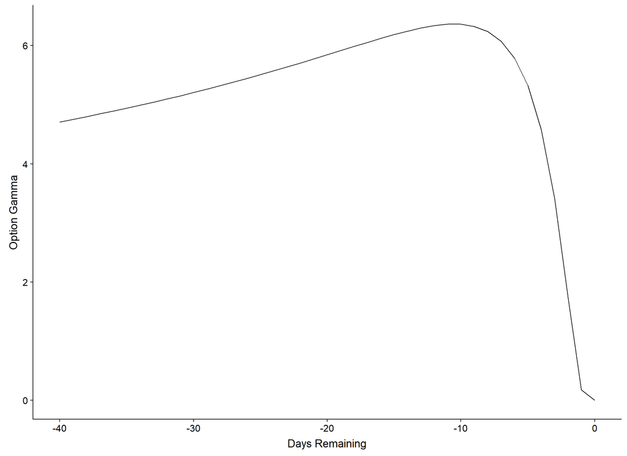

```r
days_remaining <- seq(40, 0, by = -1)

gamma_value <- sapply(days_remaining, function(iterday) {
    val <- calc_price_greeks(type          = 'call'
                            ,underlying    = 96
                            ,strike        = 100
                            ,riskFreeRate  = 0.01
                            ,maturity      = iterday / 252
                            ,dividendYield = 0
                            ,volatility    = 0.20)

    return(val['gamma'])
})

ggplot() +
    geom_line(aes(x = -days_remaining, y = gamma_value)) +
    xlab("Days Remaining") +
    ylab("Option Gamma")
```

So, if nothing happens but the passing of time, the Gamma of the option will increase, then rapidly move to zero once 10 days or less are left in the option.

Why is this relevant?

It shows that as expiration approaches, deltas change a lot. In a live environment, the stock price is moving around, meaning that when the stock is close to the strike, the change in deltas is large, and hedging deltas is likely to prove expensive and counterproductive. It also shows how options can provide significant leverage, large gammas mean that even small changes in the underlying can have a huge effect in the value of an option.

To illustrate, suppose a 20% vol stock is at 97 and there are 2 days left on an option. Suppose we buy the option, and the price opens at 99 on Friday morning (1 day left), then moves up to 100 at lunchtime, a lifetime of 0.5 days. What does the option price do?

```r
leverage_pricer <- create_line_pricer(K = 100, r = 0.01, vol = 0.20)

price1 <- leverage_pricer(S = 97,  t = 2.0 / 252)
price2 <- leverage_pricer(S = 99,  t = 1.0 / 252)
price3 <- leverage_pricer(S = 100, t = 0.5 / 252)

print(c(price1['c'], price2['c'], price3['c']), digits = 4)
```

```
##       c       c       c
## 0.03169 0.15212 0.35629
```

This non-linear response of options to changes in the underlying is why options are so complex. Get it wrong, and you can lose a lot of money very quickly.[^23]

## 3.5 Summary

My original plan for this series was to have three articles, and this final post would include discussions on the effect of volatility and how to view option contracts as insurance, but this was wishful thinking on my behalf. We will stop for now and digest all we have discussed. There is a lot going on and requires some thinking about why things behave as they do.

First we looked at the effect of time on option premium, in particular how premium erodes away as time passes and how the patterns of behaviour of this decay is different depending on the moneyness of the option. Premium in ATM options is more durable but then decays rapidly as expiration is imminent.

We then discussed non-linear behaviour and Gamma, the second derivative of the option price to changes in the underlying. In particular, we discussed how Gamma functions as a sort of accelerant for option price, greatly magnifying the profit or loss of the option due to movements in the share price.

The code used to produce all of the above graphs and numbers is available in BitBucket repo if you would like to play with it yourself. Please get in touch with any of us here if you would like access.

In the fourth and final article of this series we will discuss volatility: its effect on prices, how we think about it, and how it behaves as the underlying moves.

# 4 Fourth Post

In the final post on this series we discuss the use of options as insurance and try to bring everything together.

In the previous posts we introduced options and discussed various issues involving them - from a trading perspective and in terms of how they are priced and how they behave. In this final post we will discuss the use of options as an insurance product and how the volatility (vol) can add extra complexity to their behaviour.

## 4.1 Volatility Effects - Options as Insurance

When using options, we need to pay attention to two price levels: the price of the underlying and the volatility level. Both impact the profitability of the option so it is important to understand this behaviour: the stock price change is directional, and the volatility change is probabilistic.

When the stock price moves, the option will lose or gain value due to the delta position - calls gain from a price rise, and lose from a price drop, puts are the other way around.

Volatility is representation of the future uncertainty of how the underlying will move - think of it as the cost of insuring against price moves. Highly volatile stocks have a lot of uncertainty around where the price will be at expiration - so it is understandable that insuring movements on this stock will be more expensive.

Furthermore, the underlying price and the volatility level are not independent: vol levels react to changes in the price of the underlying (and the market as a whole). Options are forward-looking instruments, so events that impact expectations of future price changes will impact the price of the option and hence the volatility level.

To give a simple example, imagine we are trading an option on SPY, an ETF that tracks the S&P 500 Index of large public companies in the US. Thinking of the options as insurance against price movements then puts are insurance against falls in price, and calls are insurance against rises in price.

Conversely, on a good day where the share price rises, demand for insurance drops, and vol levels fall.

Thinking of an option contract as an insurance policy may also help explain why it is difficult to make money from owning options: insurance is often priced above fair value. This means the vol level implied in the option price is higher than the price in the underlying is moving.

If you own the option, the option expires in the money but less than the premium paid to buy the option - losing money overall.

On the plus side, you will not go out of business over night either, but that may be scant comfort looking at your account balance. Almost all successful option traders make money by selling options, accepting the risk that adverse market events may prove ruinous.

Diligent, informed and prudent risk management is essential for staying in business, so understanding and anticipating what will happen is hugely important.

## 4.2 Volatility Smile and Skew

```r
spy_option_dt <- read_rds("data/spy_options_20150526.rds")

head(spy_option_dt)
```

```
##      symbol       date     expiry strike callput impliedvol underlying
## 1: SPY.AMEX 2015-05-26 2015-06-26    175       C   0.369487      210.7
## 2: SPY.AMEX 2015-05-26 2015-06-26    175       P   0.270437      210.7
## 3: SPY.AMEX 2015-05-26 2015-06-26    180       C   0.326222      210.7
## 4: SPY.AMEX 2015-05-26 2015-06-26    180       P   0.246886      210.7
## 5: SPY.AMEX 2015-05-26 2015-06-26    185       C   0.283991      210.7
## 6: SPY.AMEX 2015-05-26 2015-06-26    185       P   0.226441      210.7
##    use.implied atm.implied skew.factor
## 1:    0.270437    0.122421     2.20908
## 2:    0.270437    0.122421     2.20908
## 3:    0.246886    0.122421     2.01670
## 4:    0.246886    0.122421     2.01670
## 5:    0.226441    0.122421     1.84970
## 6:    0.226441    0.122421     1.84970
```

Now we do a plot for the strike against the implied volatility and see what we get (we plot calls and puts separately). Note that the closing price for SPY on that date was 210.70 USD

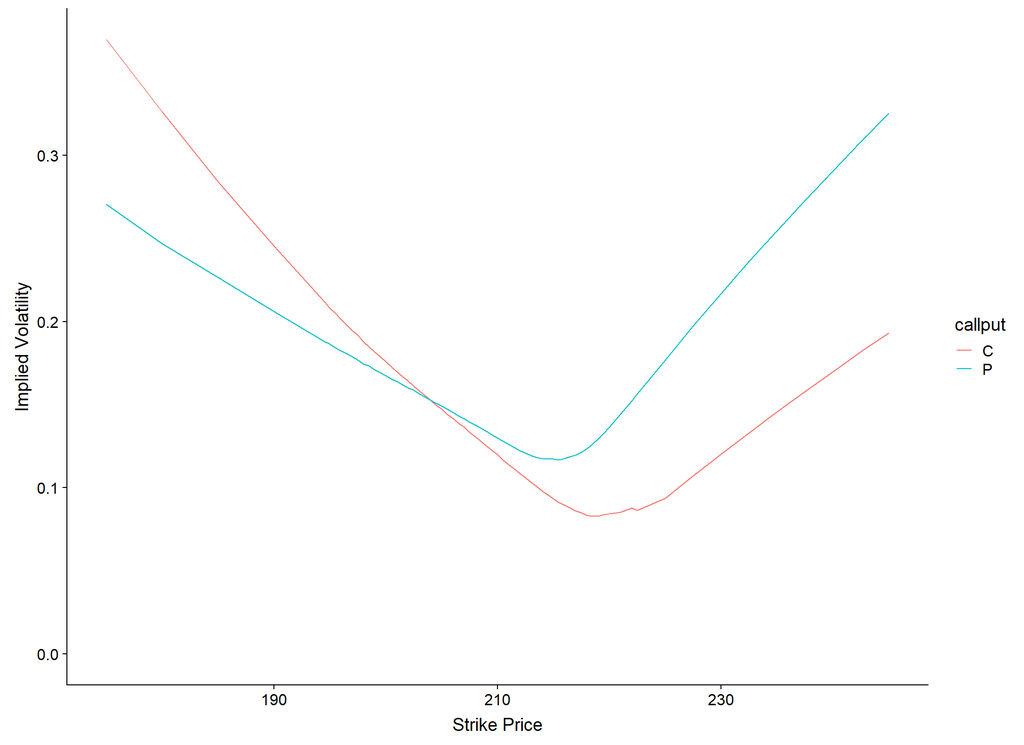

```r
ggplot(data = spy_option_dt) +
    geom_line(aes(x = strike, y = impliedvol, colour = callput)) +
    expand_limits(y = 0) +
    xlab("Strike Price") +
    ylab("Implied Volatility")
```

We see that for both calls and puts there is ‘volatility smile’ rather than a flat line. We looked at all strikes for that expiration. There will be almost no liquidity that far away from the money so we zoom in closer: we look at strikes from 190 to 230 as these options will be more liquid and hence their prices are more trustworthy:

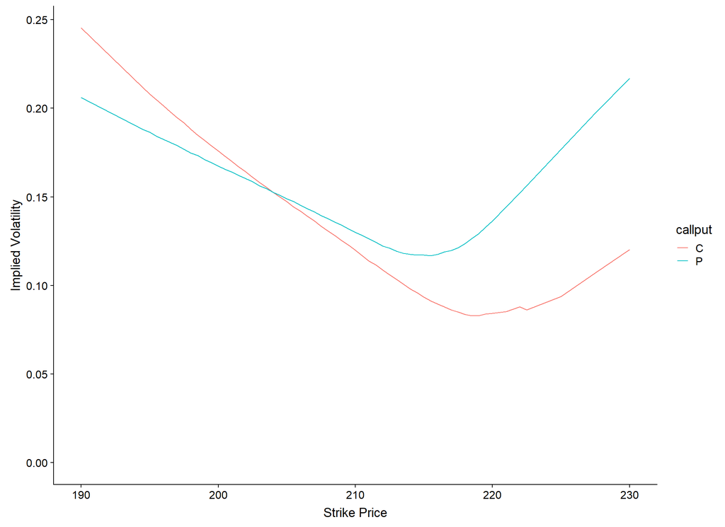

```r
ggplot(data = spy_option_dt[strike >= 190 & strike <= 230]) +
    geom_line(aes(x = strike, y = impliedvol, colour = callput)) +
    expand_limits(y = 0) +
    xlab("Strike Price") +
    ylab("Implied Volatility")
```

Implied volatility is higher both below and above the stock price - rounding out when the strikes are close to and at the money. Why might this be?

A couple of issues are at play here, so we list them first and discuss them after

- The Black-Scholes Model is Wrong
- Options are Insurance
- Trader Psychology

### 4.2.1 The Black-Scholes Model is Wrong

This assumption is known to be wrong, and has been from the very early days of option pricing theory - but as it is simplifying assumption that allows us to make progress, it is undeniably useful. Nevertheless, it is wrong. Stock price movements are not lognormal, they have much heavier tails.

Consequently, the Black Scholes model tends to underestimate the probability of larger price movements.

As an exercise, what are the implications for pricing options? Are there any?

We may guess that it has implications - and we would be right. If option pricing models systemically underestimate the probability of very large movements it means that option prices far away from the money are systemically priced too cheap. What happens to the implied vol for those strikes if we put our prices up? Implied vol has an increasing relationship with price, so the implied vols at those strikes are raised.

This makes sense - as strikes move away from the money, the prices rise above the price given by the model to account for the model error. In turn, this pulls up the implied vols as we move away from the at the money strikes creating the ‘volatility smile’.

### 4.2.2 Options are Insurance

Options are insurance policies against the movement of the underlying stock, so when we buy an option we buy an insurance policy. Another way to look at this is that someone else is selling us an insurance policy - taking on the uncertain risk of the stock moving adversely for them. As the option holder, we know how much we are putting at risk: the most we can possibly lose is the premium we paid for the option. For the seller, the opposite is true, they receive money upfront but may have to pay out much, much more in the future.

As a seller of risk, a trader wants enough premium upfront to make it worthwhile. This is more straightforward when the strike price of the sold option is around the money, but if it is far away there is more uncertainty - as we discussed, real-life price movements only approximately match the assumptions of the Black-Scholes model.

We try to think like an option seller. Suppose the volatility of a stock is around 20% and the stock is at 100. We are approached by a broker to sell 90 strike puts that expire in a month - put options deep out of the money (often called ‘deep puts’ for short).

```r
AmericanOption(type          = 'put'
              ,underlying    = 100
              ,strike        = 90
              ,dividendYield = 0
              ,riskFreeRate  = 0.01
              ,maturity      = 20/252
              ,volatility    = 0.2)
```

```
## Concise summary of valuation for AmericanOption
##  value  delta  gamma   vega  theta    rho divRho
## 0.0617     NA     NA     NA     NA     NA     NA
```

According to model, this option is worth about 6c. The stock is 10 USD above the strike, so the chances of this option expiring in the money are very slim, but if something bad does happen in the next 20 days, there is the chance to lose a lot, lot more than the 6c we earned by selling it.

There is a price for every risk though, so suppose we decide to quote 15c. What is the implied vol at this price?

```r
AmericanOptionImpliedVolatility(type          = 'put'
                               ,value         = 0.15
                               ,underlying    = 100
                               ,strike        = 90
                               ,dividendYield = 0
                               ,riskFreeRate  = 0.01
                               ,maturity      = 20/252
                               ,volatility    = 0.2)
```

```
## [1] 0.236759
## attr(,"class")
## [1] "AmericanOptionImpliedVolatility" "ImpliedVolatility"
```

By putting the price up to 15c we are now quoting an implied vol of 23.6%. This behaviour is wholly rational. Prior to the October 1987 crash, vol curves were flat, and a lot of people selling options or ‘portfolio insurance’ - a product that functioned like an option - lost a lot of money as they were not being compensated appropriately for the risk they were taking.

### 4.2.3 Trader Psychology

One final contributor to this behaviour is human nature and natural responses to asymmetric risk. In our previous example we priced at option at a strike of 90. What if the strike were 80?

```r
print(AmericanOption(type          = 'put'
                    ,underlying    = 100
                    ,strike        = 80
                    ,dividendYield = 0
                    ,riskFreeRate  = 0.01
                    ,maturity      = 20/252
                    ,volatility    = 0.2)
      ,digits = 6)
```

```
## Concise summary of valuation for AmericanOption
##   value   delta   gamma    vega   theta     rho  divRho
## 4.8e-05      NA      NA      NA      NA      NA      NA
```

According to the model, this option is worth less than 1% of 1c. No person will ever sell that risk at that price - the amount is too small and the asymmetric nature of the risk means it is not a sensible thing to do. At a very minimum, a trader may be willing to sell it for 1c, but will probably want to do it for more. We can see what vols are implied by these prices:

```r
AmericanOptionImpliedVolatility(type          = 'put'
                               ,value         = 0.01
                               ,underlying    = 100
                               ,strike        = 80
                               ,dividendYield = 0
                               ,riskFreeRate  = 0.01
                               ,maturity      = 20/252
                               ,volatility    = 0.2)
```

```
## [1] 0.301862
## attr(,"class")
## [1] "AmericanOptionImpliedVolatility" "ImpliedVolatility"
```

```r
AmericanOptionImpliedVolatility(type          = 'put'
                               ,value         = 0.03
                               ,underlying    = 100
                               ,strike        = 80
                               ,dividendYield = 0
                               ,riskFreeRate  = 0.01
                               ,maturity      = 20/252
                               ,volatility    = 0.2)
```

```
## [1] 0.342957
## attr(,"class")
## [1] "AmericanOptionImpliedVolatility" "ImpliedVolatility"
```

To get these prices of 1c and 3c we need to raise the vol to about 30% and 34% respectively.

## 4.3 Volatility Skew

We discussed the volatility smile, but often we observe a ‘volatility skew’ - vol is higher on the downside strikes than at equivalent upside strikes. The curve is not symmetric around the current stock price.

Again, we stop for a minute to think why? We observe the implied vols across the strikes and see a skew toward the downside. Can we infer anything from this?

Naturally, we can.

We discuss this further in the next section, but for now we can state that stock price movements are skewed: the tendency is to have a large number of smaller positive price moves and a smaller number of large negative moves. When the market falls, it tends to be in larger drops that happen quickly.

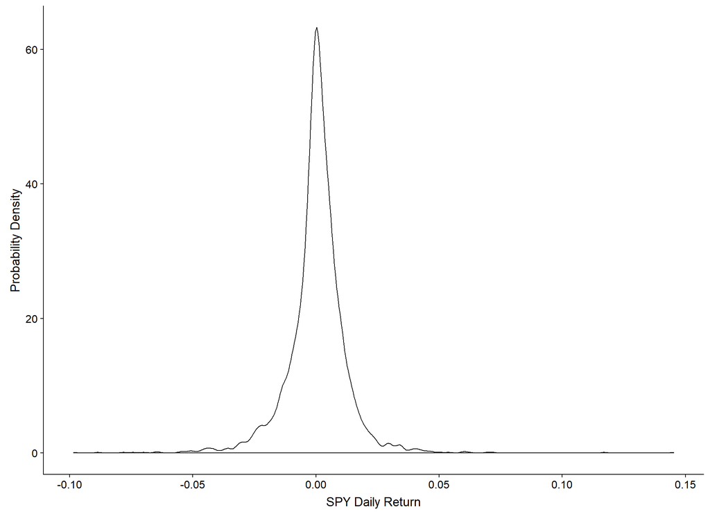

```r
spy_data_xts <- getSymbols("SPY"
                          ,start       = '1990-01-01'
                          ,end         = '2015-12-31'
                          ,type        = 'price'
                          ,auto.assign = FALSE)

spy_returns <- (spy_data_xts$SPY.Close / lag(spy_data_xts$SPY.Close))[-1] - 1

ggplot() +
    geom_density(aes(x = as.numeric(spy_returns))) +
    xlab("SPY Daily Return") +
    ylab("Probability Density")
```

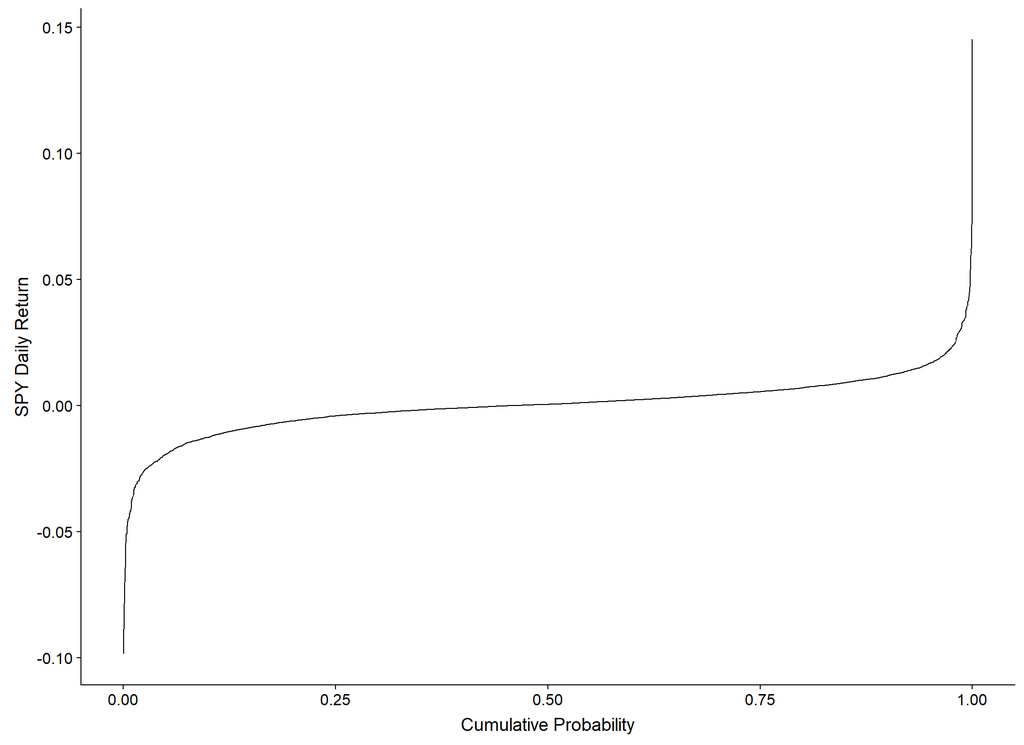

```r
ggplot() +
    geom_line(aes(x = seq_along(spy_returns) / length(spy_returns)
                 ,y = sort(as.numeric(spy_returns)))) +
    xlab("Cumulative Probability") +
    ylab("SPY Daily Return")
```

Those plots are a little surprising, the distributions are not as skewed as expected. Then again, we have been in a cyclic bull market since the early 80s due to falling interest rates so that affects the return distribution. The very large positive days in the market occurred around the Credit Crisis of 2008, and are anomalous.

The skewed distribution of returns induces the skew in the strike/implied vol curve. The skew is how the market ‘corrects’ for the mismatch between the basic assumptions of option pricing models and empirical reality.

## 4.4 Miscellanous Issues

Before we start to wrap everything up, there are a few phenomenon and issues to discuss.

### 4.4.1 Volatility and Stock Price Direction

Capital markets have a natural bias towards the bull side. A large majority of investors are long equities, and herding behaviour is common and well-known in market behaviour. Fear and greed are significant drivers of price changes.

Ignoring options for a moment, a number of patterns are observed. In a falling market, panic sets in. Most investors have long positions, and the psychological effects of loss aversion prompts selling. Trading volumes rise. This exacerbates negative moves, so negative days are larger. Unless there is a total crash, the strong selling resolves the issue faster, running its course quicker, As a result, while larger in magnitude, the count of those negative days is smaller.

Conversely, in a rising market, complacency sets in as everyone profits and is happy. Greed sets in as investors ride the wave of rising prices and do not take profits for fear of missing out of further profits, so trade volumes fall. This pattern of behaviour is well-known.

From a volatility perspective, things are a little complex. It is important to draw a clear distinction between realised volatility (the volatility of the underlying price movements), and implied volatility. Recall that implied vol is the vol input to the pricing model required to obtain the price of the options on the market.

Implied and realised vols are not the same, though they are coupled. Implied vol is best thought of as a measure of the price of insurance - higher implied vols means the option market is charging more to insure market moves. As implied vols are forward-looking in nature, implieds are likely to move ahead of the realised vol. For example, suppose a company is expected bad earnings, but releases results that are better than expected. Realised volatility in the period of time after the announcement (say a day or two) will be high are the news is digested, but implied volatilities are likely to drop. From an insurance perspective, we now have much less uncertainty about that company, so the cost of insuring it is lower.

Another observed phenomenon is that stock price and implied volatility tend to be inversely correlated - when stock prices drop, implieds go up, and vice versa. This makes sense from both a mathematical and psychological point of view.

From the mathematical point of view, when markets fall, the falls are likely to be big, and get bigger, so there is more risk. As a result, the cost of insurance goes up and implied volatilities rise. In rising markets, we have less risk: the smaller, positive rises reduce the risk of adverse events (in the short term) and so the cost of insuring it go down. Implied vols fall.

Psychologically, in falling markets people panic and want to buy insurance, caring less than they probably should about the cost. They just want the protection. Supply has not really changed despite the greater demand, so the price of insurance and implied vols rise.

In rising markets, investors get complacent and do not want insurance - why spend premium on protection you do not need? Demand drops and options sellers are willing to sell more risk as it is lower, so prices and implied vols fall.

The relationship between stock price and implied vol is loose, and is stronger for index-linked products like ETFs. For single stocks there is much more individual risk so the pattern is not as strongly observed. It is a phenomenon worth bearing in mind though, especially for someone who is long volatility - periods of calm will kill your PnL.

### 4.4.2 Option Portfolios

When trading options seriously, it is rare to own individual contracts. In fact, it is rare to have a trade involving an option alone. Often, option trades are tied to the underlying stock trade for the deltas. It is also common to trade *option spreads* - combinations of contracts mentioned in the second post in this series.

Call and put spreads are especially common: we buy and sell calls at two different strikes but with the same expiration for example. This allows people to take bearish and bullish positions while reducing the risk from trading a lone contract.

Thankfully, we can, and we can do so easily - at least for options on the same underlying. The greeks are derivatives, and can be added: if we are long 1500 delta as a result of one option contract and short 800 from another, our net delta position is long 700 deltas.

Similarly, gamma, theta, and vega are also additive so a portfolio of options can be analysed by adding all the greeks of all our option position. At a glance we can see what our net positions are in the greeks, making it easier for traders and portfolio managers to make decisions on managing risks.

That said, it is still important to pay attention to the individual contracts in the portfolio - as the composition of the portfolio will have second order effects.

To illustrate, suppose we have bought and sold a number of calls and puts from our trading on Monday, when the underlying stock was around 100 USD. As a result, we have a collection of positions with strikes ranging from 90 to 110. A few days pass, we do no trades and the stock is now around 80. Regardless of what our net greek positions are, it makes sense that the stock moving back towards 100 will be very different to the stock falling further. If the stock goes up, our overall gamma will pick up, as the stock is moving back near strikes where we have positions. If it falls, our gamma will get smaller. This will not be reflected in our aggregate Greek positions.

Reading some of the work on looking at further derivatives of $V$, such approaches may capture this additional knowledge: second derivatives like Vega-delta, $\frac{d^2V}{dS d\sigma}$, but I am not sure yet of the utlity of them. Estimating them numerically is problematic due to numerical rounding issues, etc.

I could be wrong but my intuition tells me it may be best to stick with the standard greeks and keep the composition of the portfolio in mind when doing risk assessments. That said, this is not a strongly held opinion, and could easily be wrong. It is something I can imagine myself implementing in the future despite my misgivings.

## 4.5 Final Thoughts and Conclusions

This series covered a lot of ground! We started with an explanation of what options are, how they are traded and the infrastructure that has built up around them. We then discussed some basics of option pricing and option spreads, and discussed the behaviour of option prices as the values of inputs change.

You can probably guess there is much, much more to the topic. Options seem straightforward when explained, but the practical issues of their usage is deceptively complex. The nonlinearity of their behaviour often surprises, and it is not well understood that their value is determined along two axes: the stock price and the volatility level. It is very possible to buy a call, have the stock do nothing but go up and still lose money on trade![^24]

Options, like insurance, are a fascinating topic for anyone interested in probability and statistics - and they are not well understood. It was my aim in this series to discuss some intricacies and issues I have not seen elsewhere in quantitative finance books, but there is a whole lot more in the topic.

I did not need to use too much code for this blog post series, but it is available to anyone on request - as always, get in touch with us if you have further questions or comments or would like access to the code.

Quantative finance is a huge topic, and one closely tied to actuarial studies so understanding the basics is very useful in insurance.

[^1]: A futures contract (*future*) is a simple type of derivative that allows your to buy or sell an asset today and take delivery of the asset at a future point in time. Futures differ from options in that entering into a futures contract obligates you to trade and so function in many ways like stock. I will not really discuss futures much in this article but a lot of the idiosyncratic nature of options contracts seems related to the fact that the first options exchanges were offshoots of futures exchanges. Please let me know if I am wrong about this.
[^2]: This term does make sense, and should be understood by the end of this series.
[^3]: American options will always be at least as valuable as the European equivalent as you can always decide to hold the option to expiration. Thus, it is sometimes useful to price an option as if it were European purely to obtain a lower bound on the price.
[^4]: My inner cynic also insists that the consequent erection of competitive barriers to entry plays a non-trivial role too.
[^5]: I’ve tried a few times and have never been wholly satisfied - it is a concept that tends to mean different things in different contexts, but you can usually determine some measure that is close to what you are after.
[^6]: If this surprises you, think about the expense in time and fees involved in the buying or selling of a house or piece of commercial property. It is not something you can do in a few minutes or even days, and the price is always prone to uncertainty. In contrast, you can trade a few billion USD or EUR in the currency markets in seconds or minutes without much problem.
[^7]: There are stories of traders on the New York Stock Exchange in the 1800s carrying revolvers with them when they went to settle trades with counterparties. Similarly, in the early days of poker-playing in US a lot of players were armed to ensure they left the card-rooms with their winnings.
[^8]: Of course, like all risk mitigation strategies, this means there is now a massive systemic risk of the clearing system failing. However, were that to occur, it is likely you are looking for a shotgun, a stock of canned food, and are not thinking about collecting those call options you bought.
[^9]: Back in the days of floor trading, order sizes of 10 contracts or less were often met with a derisive “would you like a lollipop with that?”
[^10]: Wilmott on Quantitative Finance is an excellent resource for this.
[^11]: An option that is *in-the-money* is an option contract where the the exercise value of the option is positive. If the exercise value is negative, the option is *out-of-the-money*.
[^12]: The options can also have different expirations, though this is generally termed a *calendar spread*.
[^13]: Even then, it is probably more fair to say that the ‘true’ value stays latent, instead observing a realization of it.
[^14]: Some traders at the desks of the larger banks had a reputation for trying to get you to honour dollar prices on trades, even when based on stale stock prices. A common response was “why don’t I just write you a cheque right now and save us all the time?”
[^15]: It is probably no surprise to learn this is a large simplification: asset volatility does not scale smoothly across time. Intra-day volatility is often higher than that measured at longer time scales.
[^16]: A common misinterpretation of this is that the ‘average move’ of the asset is then 1%, which is false. It is more like 0.80%. The correct interpretation is that you expect the movement to be 1% or less two-thirds of the time.
[^17]: Not to mention that I would probably get some technical details wrong and look stupid…
[^18]: At first glance, this may seem to only apply to calls, as the value of a put has a negative relationship to the underlying but that is not the case due to parity. This will be discussed more in the third article.
[^19]: This is approximate as vega will have a second derivative, but for small changes in vol it is close enough.
[^20]: If the market moves out of line on this, trading arbitrage will force it back. I heard a story (which I believe) that the first person to figure out that puts were the same as calls quietly made a huge fortune on the Chicago option floor with no risk
[^21]: To aid memory, moneyness describes the intrinsic value of the option. In-the-money options have positive intrinsic value. Out-of-the-money options have no intrinsic value. At-the-money options have strike prices very close to the current underlying price. Recall that delta for calls ranges from 0 to 100, and puts from -100 to 0. In terms of approaching the strike, we should technically say approach 50 (or -50) delta.
[^22]: If the price had gone through the strike and kept going, it would start to lose pace, as the gamma would start to decrease, but the options would also have intrinsic value.
[^23]: Or make it. One of my favourite trading stories which I have been unable to verify is that one of the larger trading firms today largely owes its existence to Black Monday in 1987. A market-maker in options, through pure chance they owned a huge amount of put options that were way below the market level when the crash happened. Those options, which had cost them pennies, ended up being worth 50 or 60 USD each and made the firm millions. This provided them with the capital base to grow their operations and they admitted themselves it was pure luck.
[^24]: As a quick spot test for the reader, can you think of a scenario where this happens? If you can, I will be pleased. It means I have managed to successfully convey the core concepts to at least one other person!